# Lab3

```python
import pandas as pd
import warnings
warnings.filterwarnings("ignore")
```

```python
# Read the data
cc_df = pd.read_csv('creditcard.csv')
cc_df.head()
```

|  | Time | V1 | V2 | V3 | V4 | V5 | V6 | V7 | V8 | V9 | ... | V21 | V22 | V23 | V24 | V25 | V26 | V27 | V28 | Amount | Class |
| --- | --- | --- | --- | --- | --- | --- | --- | --- | --- | --- | --- | --- | --- | --- | --- | --- | --- | --- | --- | --- | --- |
| 0 | 0.0 | -1.359807 | -0.072781 | 2.536347 | 1.378155 | -0.338321 | 0.462388 | 0.239599 | 0.098698 | 0.363787 | ... | -0.018307 | 0.277838 | -0.110474 | 0.066928 | 0.128539 | -0.189115 | 0.133558 | -0.021053 | 149.62 | 0 |
| 1 | 0.0 | 1.191857 | 0.266151 | 0.166480 | 0.448154 | 0.060018 | -0.082361 | -0.078803 | 0.085102 | -0.255425 | ... | -0.225775 | -0.638672 | 0.101288 | -0.339846 | 0.167170 | 0.125895 | -0.008983 | 0.014724 | 2.69 | 0 |
| 2 | 1.0 | -1.358354 | -1.340163 | 1.773209 | 0.379780 | -0.503198 | 1.800499 | 0.791461 | 0.247676 | -1.514654 | ... | 0.247998 | 0.771679 | 0.909412 | -0.689281 | -0.327642 | -0.139097 | -0.055353 | -0.059752 | 378.66 | 0 |
| 3 | 1.0 | -0.966272 | -0.185226 | 1.792993 | -0.863291 | -0.010309 | 1.247203 | 0.237609 | 0.377436 | -1.387024 | ... | -0.108300 | 0.005274 | -0.190321 | -1.175575 | 0.647376 | -0.221929 | 0.062723 | 0.061458 | 123.50 | 0 |
| 4 | 2.0 | -1.158233 | 0.877737 | 1.548718 | 0.403034 | -0.407193 | 0.095921 | 0.592941 | -0.270533 | 0.817739 | ... | -0.009431 | 0.798278 | -0.137458 | 0.141267 | -0.206010 | 0.502292 | 0.219422 | 0.215153 | 69.99 | 0 |

5 rows × 31 columns

```python
# printing the columns
print(cc_df.columns)

# checking the shape of the data
print("Shape - ", cc_df.shape)

# checking the data types
print("Dtypes - \n", cc_df.dtypes)
```

```
Index(['Time', 'V1', 'V2', 'V3', 'V4', 'V5', 'V6', 'V7', 'V8', 'V9', 'V10',
       'V11', 'V12', 'V13', 'V14', 'V15', 'V16', 'V17', 'V18', 'V19', 'V20',
       'V21', 'V22', 'V23', 'V24', 'V25', 'V26', 'V27', 'V28', 'Amount',
       'Class'],
      dtype='object')
Shape -  (284807, 31)
Dtypes -
 Time      float64
V1        float64
V2        float64
V3        float64
V4        float64
V5        float64
V6        float64
V7        float64
V8        float64
V9        float64
V10       float64
V11       float64
V12       float64
V13       float64
V14       float64
V15       float64
V16       float64
V17       float64
V18       float64
V19       float64
V20       float64
V21       float64
V22       float64
V23       float64
V24       float64
V25       float64
V26       float64
V27       float64
V28       float64
Amount    float64
Class       int64
dtype: object
```

```python
#checking the missing values
print("Missing values \n", cc_df.isnull().sum())
```

```
Missing values
 Time      0
V1        0
V2        0
V3        0
V4        0
V5        0
V6        0
V7        0
V8        0
V9        0
V10       0
V11       0
V12       0
V13       0
V14       0
V15       0
V16       0
V17       0
V18       0
V19       0
V20       0
V21       0
V22       0
V23       0
V24       0
V25       0
V26       0
V27       0
V28       0
Amount    0
Class     0
dtype: int64
```

```python
##detecting and handling outliers
# Extract numerical columns
numerical_columns = cc_df.select_dtypes(include=['float64']).columns

# Calculate the IQR for each numerical feature
Q1 = cc_df[numerical_columns].quantile(0.25)
Q3 = cc_df[numerical_columns].quantile(0.75)
IQR = Q3 - Q1

# Define the upper and lower bounds for outliers
lower_bound = Q1 - 1.5 * IQR
upper_bound = Q3 + 1.5 * IQR

# Identify and handle outliers
outliers_removed_df = cc_df.copy()
for column in numerical_columns:
    outliers_removed_df = outliers_removed_df.loc[
        (outliers_removed_df[column] >= lower_bound[column]) &
        (outliers_removed_df[column] <= upper_bound[column])
    ]

# Print the shape of the data before and after
print("Shape before removing outliers - ", cc_df.shape)
print("Shape after removing outliers - ", outliers_removed_df.shape)
```

```
Shape before removing outliers -  (284807, 31)
Shape after removing outliers -  (146334, 31)
```

```python
cc_df = outliers_removed_df
```

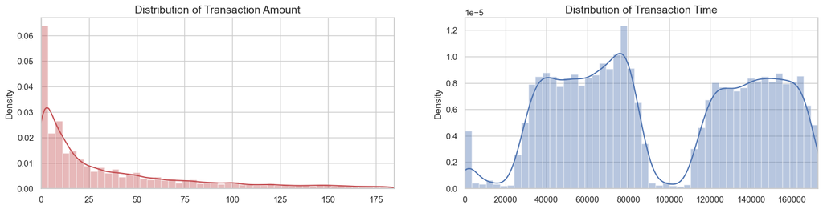

```python
# Visualizing the data
import matplotlib.pyplot as plt
import seaborn as sns

# Plot the distribution of Time and Amount

fig, ax = plt.subplots(1, 2, figsize=(18,4))

amount_val = cc_df['Amount'].values
time_val = cc_df['Time'].values

sns.distplot(amount_val, ax=ax[0], color='r')
ax[0].set_title('Distribution of Transaction Amount', fontsize=14)
ax[0].set_xlim([min(amount_val), max(amount_val)])

sns.distplot(time_val, ax=ax[1], color='b')
ax[1].set_title('Distribution of Transaction Time', fontsize=14)
ax[1].set_xlim([min(time_val), max(time_val)])

plt.show()
```

**Now the outliers are removed and data is cleaned**  
**We can use min-max scaling as it maintains distribution of the data**

```python
from sklearn.preprocessing import MinMaxScaler

# Extract the numerical features
numerical_features = ['Time', 'Amount'] + [f'V{i}' for i in range(1, 29)]

# Create a MinMaxScaler object
scaler = MinMaxScaler()

# Fit the scaler on the numerical features and transform them
cc_df[numerical_features] = scaler.fit_transform(cc_df[numerical_features])
cc_df.shape
```

```
(146334, 31)
```

**Analyzing fraud vs non-fraud transactions**

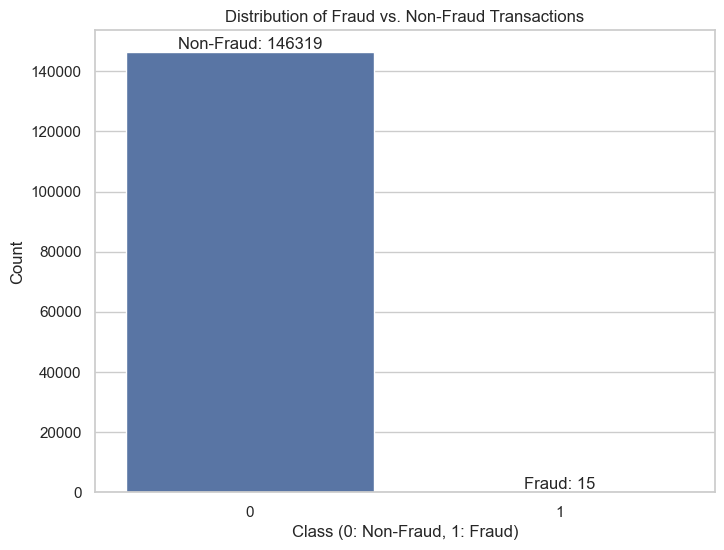

```python
#fraud vs non-fraud visualization

plt.figure(figsize=(8, 6))

# Countplot to visualize the distribution of fraud vs. non-fraud transactions
sns.countplot(x='Class', data=cc_df)
plt.title('Distribution of Fraud vs. Non-Fraud Transactions')
plt.xlabel('Class (0: Non-Fraud, 1: Fraud)')
plt.ylabel('Count')

# Display the count of each class
fraud_count = cc_df['Class'].value_counts()[1]
non_fraud_count = cc_df['Class'].value_counts()[0]
plt.text(0, non_fraud_count, f'Non-Fraud: {non_fraud_count}', ha='center', va='bottom')
plt.text(1, fraud_count, f'Fraud: {fraud_count}', ha='center', va='bottom')

plt.show()
```

**From the graph it is to be observed that it is a highly imbalanced dataset having non fraud transactons significantly larger then fraud transactions**

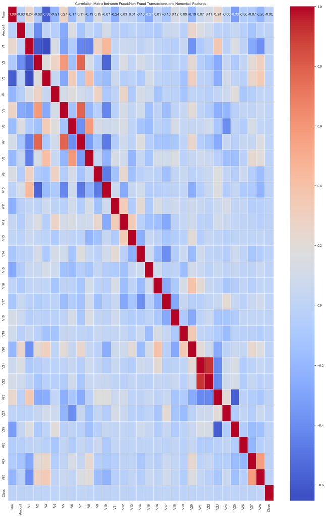

```python
##Identifying the correlation fraud/non-fraud to other features
plt.figure(figsize=(20, 30))

# Selecting numerical features
numerical_features = ['Time', 'Amount'] + [f'V{i}' for i in range(1, 29)]

# Adding the target variable 'Class' to the correlation matrix
correlation_matrix = cc_df[numerical_features + ['Class']].corr()

# Heatmap to visualize the correlation matrix
sns.heatmap(correlation_matrix, annot=True, cmap='coolwarm', fmt=".2f", linewidths=0.5)
plt.title('Correlation Matrix between Fraud/Non-Fraud Transactions and Numerical Features')
plt.show()
```

```python
# Printing the correlation matrix
print(correlation_matrix['Class'].abs().sort_values(ascending=False))
```

```
Class     1.000000
V14       0.012567
V4        0.009452
V17       0.008973
V19       0.008324
V2        0.007927
V5        0.006523
V16       0.006280
V23       0.006103
V7        0.005647
Time      0.004837
V18       0.004756
V11       0.004570
V9        0.004078
V25       0.003670
V10       0.003546
V13       0.003517
V12       0.003404
V26       0.003176
V27       0.002895
Amount    0.002288
V1        0.002218
V3        0.001260
V21       0.001031
V8        0.001003
V15       0.000998
V6        0.000990
V28       0.000618
V22       0.000456
V24       0.000291
V20       0.000007
Name: Class, dtype: float64
```

**Top 3 Features having highest correlation with the target variables are V14, V4, V17 whereas V20 is the feature having lowest correaltion with class feature**

**Correlation matrix gives us the features having highest correlation with the target variable in order**

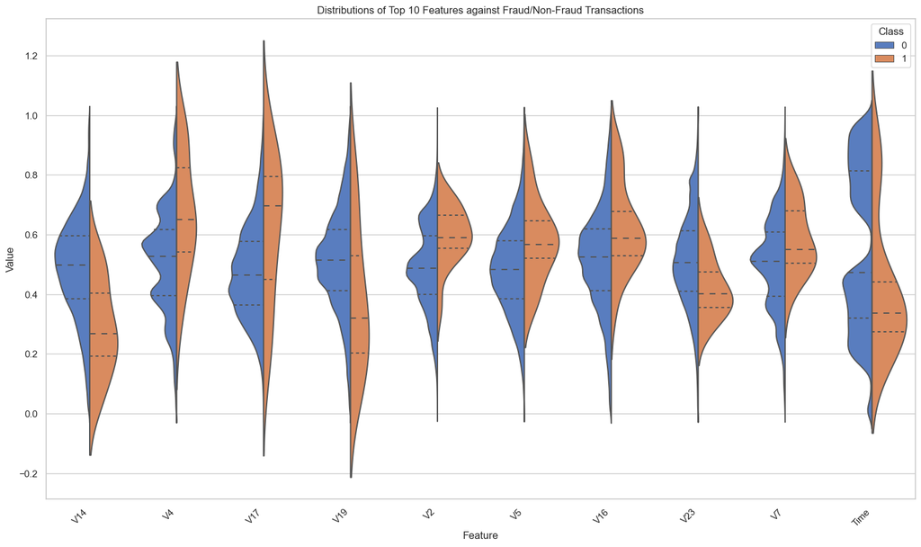

```python
##Plotting the top 10 features having highest correlation with 'Class'

# Get the top 10 features with highest correlation with 'Class'
top_features = class_correlations[1:11].index  # Excluding 'Class' itself

# Select only the relevant columns for visualization
selected_data = cc_df[['Class'] + list(top_features)]

# Melt the DataFrame to create a 'tidy' format for seaborn
melted_data = pd.melt(selected_data, id_vars='Class', var_name='Feature', value_name='Value')

# Plot distributions of the top features for fraud and non-fraud transactions
plt.figure(figsize=(18, 10))
sns.set(style="whitegrid")

# Use a violin plot for visualization
sns.violinplot(x='Feature', y='Value', hue='Class', data=melted_data, split=True, inner='quart', palette='muted')
plt.title('Distributions of Top 10 Features against Fraud/Non-Fraud Transactions')
plt.xlabel('Feature')
plt.ylabel('Value')

plt.xticks(rotation=45, ha='right')  # Rotate x-axis labels for better readability
plt.show()
```

```python
##Splitting the data into train and test
from sklearn.model_selection import train_test_split

X = cc_df.drop('Class', axis=1)
y = cc_df['Class']

X_train, X_test, y_train, y_test = train_test_split(X, y, test_size=0.2, random_state=42)

# Verify the shapes of the resulting sets
print("X_train shape:", X_train.shape)
print("X_test shape:", X_test.shape)
print("y_train shape:", y_train.shape)
print("y_test shape:", y_test.shape)
```

```
X_train shape: (117067, 30)
X_test shape: (29267, 30)
y_train shape: (117067,)
y_test shape: (29267,)
```

**Training logistic regression as a baseline model**

```python
from sklearn.model_selection import cross_val_predict
from sklearn.linear_model import LogisticRegression
from sklearn.metrics import accuracy_score, precision_score, recall_score, f1_score

# Train a logistic regression model with 5-fold cross-validation
baseline_model = LogisticRegression(random_state=42)
y_pred_cv = cross_val_predict(baseline_model, X_train, y_train, cv=5)

# Evaluate performance metrics on the training set
accuracy_cv = accuracy_score(y_train, y_pred_cv)
precision_cv = precision_score(y_train, y_pred_cv)
recall_cv = recall_score(y_train, y_pred_cv)
f1_cv = f1_score(y_train, y_pred_cv)

# Print the results on the training set
print("Cross-validated performance on the training set:")
print(f"Accuracy: {accuracy_cv:.4f}")
print(f"Precision: {precision_cv:.4f}")
print(f"Recall: {recall_cv:.4f}")
print(f"F1-Score: {f1_cv:.4f}")

# Evaluate the model on the test set
baseline_model.fit(X_train, y_train)  # Fit the model on the entire training set
y_pred_test = baseline_model.predict(X_test)

# Evaluate performance metrics on the test set
accuracy_test = accuracy_score(y_test, y_pred_test)
precision_test = precision_score(y_test, y_pred_test)
recall_test = recall_score(y_test, y_pred_test)
f1_test = f1_score(y_test, y_pred_test)

# Print the results on the test set
print("\nPerformance on the test set:")
print(f"Accuracy: {accuracy_test:.4f}")
print(f"Precision: {precision_test:.4f}")
print(f"Recall: {recall_test:.4f}")
print(f"F1-Score: {f1_test:.4f}")
```

```
Cross-validated performance on the training set:
Accuracy: 0.9999
Precision: 0.0000
Recall: 0.0000
F1-Score: 0.0000

Performance on the test set:
Accuracy: 0.9999
Precision: 0.0000
Recall: 0.0000
F1-Score: 0.0000
```

As the data set is highly imbalanced hence explains the accuracy score of 99.9%, However F1 score shows the actual score which is 0%

```python
# Access feature names and their coefficients
coefficients = baseline_model.coef_[0]
feature_names = X_train.columns

# Create a dictionary to store feature names and their corresponding coefficients
feature_coefficients = dict(zip(feature_names, coefficients))

# Print feature names and their coefficients, sorted by coefficient magnitude
sorted_features = sorted(feature_coefficients.items(), key=lambda x: abs(x[1]), reverse=True)

print("Feature weights:")
for feature, coef in sorted_features:
    print(f"{feature}: {coef:.4f}")
```

```
Feature weights:
V14: -1.8360
V17: 1.3472
V19: -1.1564
V4: 1.1001
V18: 0.9978
Time: -0.9335
V2: 0.7983
V10: -0.7680
V13: -0.7640
V16: 0.7155
V5: 0.6937
V12: -0.6764
V7: 0.6747
V15: 0.6439
V23: -0.5831
V11: 0.5241
V26: -0.5041
Amount: -0.3040
V9: -0.2707
V27: -0.2620
V25: 0.2511
V20: -0.2402
V8: -0.2186
V1: -0.1439
V24: -0.0738
V21: 0.0682
V22: 0.0391
V6: -0.0353
V28: -0.0188
V3: -0.0113
```

Which shows that model gives higher weight to the **V14** feature as it has highest correlation with the target feature

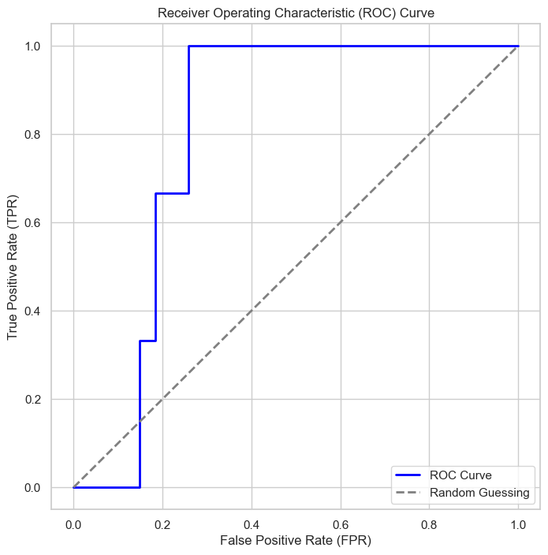

```
AUC: 0.8032
```

```python
from sklearn.metrics import roc_curve, roc_auc_score
import matplotlib.pyplot as plt

# Make predictions on the test set
y_prob = baseline_model.predict_proba(X_test)[:, 1]

# Calculate the ROC curve
fpr, tpr, thresholds = roc_curve(y_test, y_prob)

# Plot the ROC curve
plt.figure(figsize=(8, 8))
plt.plot(fpr, tpr, color='blue', lw=2, label='ROC Curve')
plt.plot([0, 1], [0, 1], color='gray', linestyle='--', lw=2, label='Random Guessing')

plt.title('Receiver Operating Characteristic (ROC) Curve')
plt.xlabel('False Positive Rate (FPR)')
plt.ylabel('True Positive Rate (TPR)')
plt.legend()
plt.show()

# Calculate the AUC
auc = roc_auc_score(y_test, y_prob)
print(f"AUC: {auc:.4f}")
```

According to ROC curve the model is better at just random guessing which is also indicated by the value of AUC

**Applying SMOTE technique to handle the class imbalance**

```python
from imblearn.over_sampling import SMOTE
from sklearn.model_selection import train_test_split
from sklearn.metrics import accuracy_score, precision_score, recall_score, f1_score, roc_auc_score
from sklearn.linear_model import LogisticRegression

X_train, X_test, y_train, y_test = train_test_split(X, y, test_size=0.2, random_state=42)

# Apply SMOTE to the training set
smote = SMOTE(random_state=42)
X_train_smote, y_train_smote = smote.fit_resample(X_train, y_train)

# Train a logistic regression model without SMOTE
baseline_model = LogisticRegression(random_state=42)
baseline_model.fit(X_train, y_train)

# Train a logistic regression model with SMOTE
model_with_smote = LogisticRegression(random_state=42)
model_with_smote.fit(X_train_smote, y_train_smote)

# Evaluate performance without SMOTE
y_pred_baseline = baseline_model.predict(X_test)
auc_baseline = roc_auc_score(y_test, baseline_model.predict_proba(X_test)[:, 1])

# Evaluate performance with SMOTE
y_pred_smote = model_with_smote.predict(X_test)
auc_smote = roc_auc_score(y_test, model_with_smote.predict_proba(X_test)[:, 1])

# Print results
print("Without SMOTE:")
print(f"AUC: {auc_baseline:.4f}")
print("Performance metrics:")
print(f"Accuracy: {accuracy_score(y_test, y_pred_baseline):.4f}")
print(f"Precision: {precision_score(y_test, y_pred_baseline):.4f}")
print(f"Recall: {recall_score(y_test, y_pred_baseline):.4f}")
print(f"F1-Score: {f1_score(y_test, y_pred_baseline):.4f}")

print("\nWith SMOTE:")
print(f"AUC: {auc_smote:.4f}")
print("Performance metrics:")
print(f"Accuracy: {accuracy_score(y_test, y_pred_smote):.4f}")
print(f"Precision: {precision_score(y_test, y_pred_smote):.4f}")
print(f"Recall: {recall_score(y_test, y_pred_smote):.4f}")
print(f"F1-Score: {f1_score(y_test, y_pred_smote):.4f}")
```

```
Without SMOTE:
AUC: 0.8032
Performance metrics:
Accuracy: 0.9999
Precision: 0.0000
Recall: 0.0000
F1-Score: 0.0000

With SMOTE:
AUC: 0.7315
Performance metrics:
Accuracy: 0.9292
Precision: 0.0005
Recall: 0.3333
F1-Score: 0.0010
```

```python
from sklearn.neighbors import KNeighborsClassifier
from sklearn.svm import SVC
from sklearn.metrics import accuracy_score, precision_score, recall_score, f1_score, roc_auc_score

# Train KNN
knn_model = KNeighborsClassifier(n_neighbors=5)
knn_model.fit(X_train, y_train)

# Train SVM
svm_model = SVC(probability=True, random_state=42)
svm_model.fit(X_train, y_train)

# Evaluate Logistic Regression
y_pred_lr = baseline_model.predict(X_test)
auc_lr = roc_auc_score(y_test, baseline_model.predict_proba(X_test)[:, 1])

# Evaluate KNN
y_pred_knn = knn_model.predict(X_test)
auc_knn = roc_auc_score(y_test, knn_model.predict_proba(X_test)[:, 1])

# Evaluate SVM
y_pred_svm = svm_model.predict(X_test)
auc_svm = roc_auc_score(y_test, svm_model.predict_proba(X_test)[:, 1])

# Print results
print("Logistic Regression:")
print(f"AUC: {auc_lr:.4f}")
print("Performance metrics:")
print(f"Accuracy: {accuracy_score(y_test, y_pred_lr):.4f}")
print(f"Precision: {precision_score(y_test, y_pred_lr):.4f}")
print(f"Recall: {recall_score(y_test, y_pred_lr):.4f}")
print(f"F1-Score: {f1_score(y_test, y_pred_lr):.4f}")

print("\nK-Nearest Neighbors:")
print(f"AUC: {auc_knn:.4f}")
print("Performance metrics:")
print(f"Accuracy: {accuracy_score(y_test, y_pred_knn):.4f}")
print(f"Precision: {precision_score(y_test, y_pred_knn):.4f}")
print(f"Recall: {recall_score(y_test, y_pred_knn):.4f}")
print(f"F1-Score: {f1_score(y_test, y_pred_knn):.4f}")

print("\nSupport Vector Machine:")
print(f"AUC: {auc_svm:.4f}")
print("Performance metrics:")
print(f"Accuracy: {accuracy_score(y_test, y_pred_svm):.4f}")
print(f"Precision: {precision_score(y_test, y_pred_svm):.4f}")
print(f"Recall: {recall_score(y_test, y_pred_svm):.4f}")
print(f"F1-Score: {f1_score(y_test, y_pred_svm):.4f}")
```

```
Logistic Regression:
AUC: 0.8032
Performance metrics:
Accuracy: 0.9999
Precision: 0.0000
Recall: 0.0000
F1-Score: 0.0000

K-Nearest Neighbors:
AUC: 0.4997
Performance metrics:
Accuracy: 0.9999
Precision: 0.0000
Recall: 0.0000
F1-Score: 0.0000

Support Vector Machine:
AUC: 0.5553
Performance metrics:
Accuracy: 0.9999
Precision: 0.0000
Recall: 0.0000
F1-Score: 0.0000
```

As the majority class dominates by high margin hence all the models achieved high accuracy but struggled with precision, recall and F1 score which means models are not effectively capturing minority class.  
Also the AUC values of SVM and KNN are close to 0.5 indicating poor discriminative power.